# Reading and Manipulating Trajectory Data in R

### By Andrew Teakles

##### 201-401 Burrard St

##### Vancouver, V6C 3S5

##### May 22, 2014

This document demonstrate how to tailor an ascii read function to ingest HYSPLIT Trajectory data. An archive of HYSPLIT files are aggregated together then visualized in **ggplot**. Afterwards, the coordinate data is compiled into shapefiles within R and then rasterized using the **raster** package.

### 1. List Trajectory Files and Filter as needed.

This example study collected a series of HYSPLIT back-trajectories with a variety of receptor heights

```r
library("stringr")
library("plyr")

HYSPLIT_dir = "./Trajectories/"
traj_files_all = list.files(HYSPLIT_dir)
head(traj_files_all)
```

```
## [1] "traj(back)-00-01-01-00-lat_45.24423_long_-78.89389-height_1000-48h"
## [2] "traj(back)-00-01-01-03-lat_45.24423_long_-78.89389-height_1000-48h"
## [3] "traj(back)-00-01-01-06-lat_45.24423_long_-78.89389-height_1000-48h"
## [4] "traj(back)-00-01-01-09-lat_45.24423_long_-78.89389-height_1000-48h"
## [5] "traj(back)-00-01-01-12-lat_45.24423_long_-78.89389-height_1000-48h"
## [6] "traj(back)-00-01-01-15-lat_45.24423_long_-78.89389-height_1000-48h"
```

```r
# HYSPLIT_dir='./Trajectories/'
traj_files_1000m = list.files(HYSPLIT_dir, pattern = glob2rx("*-height_1000-*"),
    full.names = TRUE)
head(traj_files_1000m)
```

```
## [1] "./Trajectories/traj(back)-00-01-01-00-lat_45.24423_long_-78.89389-height_1000-48h"
## [2] "./Trajectories/traj(back)-00-01-01-03-lat_45.24423_long_-78.89389-height_1000-48h"
## [3] "./Trajectories/traj(back)-00-01-01-06-lat_45.24423_long_-78.89389-height_1000-48h"
## [4] "./Trajectories/traj(back)-00-01-01-09-lat_45.24423_long_-78.89389-height_1000-48h"
## [5] "./Trajectories/traj(back)-00-01-01-12-lat_45.24423_long_-78.89389-height_1000-48h"
## [6] "./Trajectories/traj(back)-00-01-01-15-lat_45.24423_long_-78.89389-height_1000-48h"
```

```r
readLines(traj_files_1000m[1])
```

```
##  [1] "     3     1"
##  [2] "    CDC1    99    12     1     0     0"
##  [3] "    CDC1     0     1     1     0     0"
##  [4] "    CDC1     0     2     1     0     0"
##  [5] "     1 BACKWARD OMEGA   "
##  [6] "     0     1     1     0   45.244  -78.894  1000.0"
##  [7] "     1 PRESSURE"
##  [8] "     1     1     0     1     1     0     0     0     0.0   45.244  -78.894   1000.0    867.9"
##  [9] "     1     1    99    12    31    23     0     0    -1.0   45.224  -79.471   1000.6    867.9"
## [10] "     1     1    99    12    31    22     0     0    -2.0   45.206  -80.047    994.4    868.9"
## [11] "     1     1    99    12    31    21     0     0    -3.0   45.194  -80.628    981.3    870.3"
## [12] "     1     1    99    12    31    20     0     0    -4.0   45.192  -81.217    962.5    872.2"
## [13] "     1     1    99    12    31    19     0     0    -5.0   45.209  -81.821    938.9    874.4"
## [14] "     1     1    99    12    31    18     0     0    -6.0   45.253  -82.446    911.7    876.6"
## [15] "     1     1    99    12    31    17     0     0    -7.0   45.308  -83.068    886.2    879.3"
```

[output cut: 41 more lines]

###Reading HYSPLIT Trajectories Once the text for the HYSPLIT trajectory is read into R it can be parsed by separating the header information from the data block that contains the coordinates for the trajectory points. The HYSPLIT header varies in length based how many trajectories are requested and how meteorological data is used to build the file. After adjusting for this variation, the 5 records (http://ready.arl.noaa.gov/HYSPLIT_trajinfo.php) stored in the header can be read and parsed into a named list format.

#### HYSPLIT Header Read Function

```r
read_HYSPLIT_header = function(x) {
    # RECORD 1
    rec1_names = c("num_of_met_grids", "traj_num")
    rec2_names = c("met_Model_id", "start_Year", "Month", "Day", "Hour", "fcst_Hour")
    rec3_names = c("num_of_traj", "dir_of_traj_calc", "vertical_motion_calc_method")
    rec4_names = c("start_year", "month", "day", "hour", "start_lat", "start_lon",
        "start_height")
    rec5_names = c("num_diag_vars", "label_varid")
    # Read RECORD 1
    rec1 = read.fwf(x, widths = c(6, 6), header = FALSE, n = 1, col.names = rec1_names)
    ngrids = as.numeric(rec1$num_of_met_grids[1])
    # Read RECORD 2
    rec2 = read.fwf(x, widths = c(8, rep(x = 6, times = 5)), header = FALSE,
        skip = 1, n = ngrids, col.names = rec2_names)
    # Read RECORD 3
    rec3 = read.fwf(x, widths = c(6, rep(x = 9, times = 2)), header = FALSE,
        skip = ngrids + 1, n = 1, col.names = rec3_names, stringsAsFactors = FALSE)  #use stringsAsFactors to avoid conversion to Factor prematurely
    # get rid of extra whitespace around vertical motion type
    rec3$vertical_motion_calc_method = str_trim(rec3$vertical_motion_calc_method)
    ntraj = as.numeric(rec3$num_of_traj[1])
    # Read RECORD 4
    rec4 = read.fwf(x, widths = c(rep(x = 6, times = 4), rep(9, times = 3)),
        header = FALSE, skip = ngrids + 2, n = ntraj, col.names = rec4_names)
    # Read RECORD 5 TO ADJUSTS FOR MORE THAN 1 DIAG
    num_diag = read.fwf(x, widths = c(6), header = FALSE, skip = ngrids + 2 +
        ntraj, n = 1, col.names = rec5_names[1])$num_diag_vars
    # Read RECORD 5 AGAIN
    rec5 = read.fwf(x, widths = c(6, rep(9, times = num_diag)), header = FALSE,
        skip = ngrids + 2 + ntraj, n = 1, col.names = c(rec5_names[1], paste0(rec5_names[2],
            seq(num_diag))), stringsAsFactors = FALSE)
    # BUILD OUTPUT LIST FORMAT NAMED BY RECORD NUMBER
    rec_list = list(rec1, rec2, rec3, rec4, rec5)
    names(rec_list) = c("rec1", "rec2", "rec3", "rec4", "rec5")
    return(rec_list)

}
read_HYSPLIT_header(traj_files_1000m[1])
```

```
## $rec1
##   num_of_met_grids traj_num
## 1                3        1
##
## $rec2
##   met_Model_id start_Year Month Day Hour fcst_Hour
## 1         CDC1         99    12   1    0         0
## 2         CDC1          0     1   1    0         0
## 3         CDC1          0     2   1    0         0
##
## $rec3
##   num_of_traj dir_of_traj_calc vertical_motion_calc_method
## 1           1         BACKWARD                       OMEGA
##
## $rec4
##   start_year month day hour start_lat start_lon start_height
## 1          0     1   1    0     45.24    -78.89         1000
##
## $rec5
##   num_diag_vars label_varid1
## 1             1     PRESSURE
```

#### HYSPLIT Coordinate Data

Now use the header information to read the rest of the file information and adjust the column labels

```r
read_HYSPLIT = function(x) {
    header = read_HYSPLIT_header(x)
    header_len = sum(laply(header, nrow))
    rec6_names = c("traj_num", "met_grid_num", "year", "month", "day", "hour",
        "minute", "fcst_hour", "traj_age_in_hours", "lat", "lon", "height_AGL_in_m")
    varid = header$rec5[1, -1]
    rec6_names = str_trim(c(rec6_names, varid))  #adjust record column names
    rec6 = read.fwf(x, widths = c(rep(6, times = 8), 8, rep(9, times = 3 + length(varid))),
        header = FALSE, skip = 8, col.names = rec6_names)
}
head(traj_files_1000m)
```

```
## [1] "./Trajectories/traj(back)-00-01-01-00-lat_45.24423_long_-78.89389-height_1000-48h"
## [2] "./Trajectories/traj(back)-00-01-01-03-lat_45.24423_long_-78.89389-height_1000-48h"
## [3] "./Trajectories/traj(back)-00-01-01-06-lat_45.24423_long_-78.89389-height_1000-48h"
## [4] "./Trajectories/traj(back)-00-01-01-09-lat_45.24423_long_-78.89389-height_1000-48h"
## [5] "./Trajectories/traj(back)-00-01-01-12-lat_45.24423_long_-78.89389-height_1000-48h"
## [6] "./Trajectories/traj(back)-00-01-01-15-lat_45.24423_long_-78.89389-height_1000-48h"
```

```r
HYSPLIT_data = read_HYSPLIT(traj_files_1000m[1])
head(HYSPLIT_data, 15)
```

```
##    traj_num met_grid_num year month day hour minute fcst_hour
## 1         1            1   99    12  31   23      0         0
## 2         1            1   99    12  31   22      0         0
## 3         1            1   99    12  31   21      0         0
## 4         1            1   99    12  31   20      0         0
## 5         1            1   99    12  31   19      0         0
## 6         1            1   99    12  31   18      0         0
## 7         1            1   99    12  31   17      0         0
## 8         1            1   99    12  31   16      0         0
## 9         1            1   99    12  31   15      0         0
## 10        1            1   99    12  31   14      0         0
## 11        1            1   99    12  31   13      0         0
## 12        1            1   99    12  31   12      0         0
## 13        1            1   99    12  31   11      0         0
## 14        1            1   99    12  31   10      0         0
```

[output cut: 17 more lines]

### Using the **plyr** package to process multiple HYSPLIT files

The next step is to use the **plyr** package to read a collection of trajectory files and organize the data by filename.

#### Storing headers from multiple HYSPLIT files into a list

First do this for the header data using llply with will take the list of filenames and return an list of the headers labelled by their name

```r
library("plyr")
library("stringr")
HYSPLIT_headers = llply(traj_files_1000m[1:100], read_HYSPLIT_header)
names(HYSPLIT_headers) = basename(traj_files_1000m[1:100])
HYSPLIT_headers[[1]]
```

```
## $rec1
##   num_of_met_grids traj_num
## 1                3        1
##
## $rec2
##   met_Model_id start_Year Month Day Hour fcst_Hour
## 1         CDC1         99    12   1    0         0
## 2         CDC1          0     1   1    0         0
## 3         CDC1          0     2   1    0         0
##
## $rec3
##   num_of_traj dir_of_traj_calc vertical_motion_calc_method
## 1           1         BACKWARD                       OMEGA
##
## $rec4
##   start_year month day hour start_lat start_lon start_height
## 1          0     1   1    0     45.24    -78.89         1000
##
## $rec5
##   num_diag_vars label_varid1
## 1             1     PRESSURE
```

#### Storing Coordinates from multiple HYSPLIT files into a large dataframe

Also do a similar task with the coordinate data except use the **ldply** to return the resulting trajectory data as an aggregated dataframe of all the trajectories.

```r
HYSPLIT_data = ldply(traj_files_1000m[1:100], function(x) {
    out = read_HYSPLIT(x)
    out$filename = x
    return(out)
})
nrow(HYSPLIT_data)
```

```
## [1] 4800
```

```r
head(HYSPLIT_data)
```

```
##   traj_num met_grid_num year month day hour minute fcst_hour
## 1        1            1   99    12  31   23      0         0
## 2        1            1   99    12  31   22      0         0
## 3        1            1   99    12  31   21      0         0
## 4        1            1   99    12  31   20      0         0
## 5        1            1   99    12  31   19      0         0
## 6        1            1   99    12  31   18      0         0
##   traj_age_in_hours   lat    lon height_AGL_in_m PRESSURE
## 1                -1 45.22 -79.47          1000.6    867.9
## 2                -2 45.21 -80.05           994.4    868.9
## 3                -3 45.19 -80.63           981.3    870.3
## 4                -4 45.19 -81.22           962.5    872.2
## 5                -5 45.21 -81.82           938.9    874.4
## 6                -6 45.25 -82.45           911.7    876.6
##                                                                            filename
## 1 ./Trajectories/traj(back)-00-01-01-00-lat_45.24423_long_-78.89389-height_1000-48h
## 2 ./Trajectories/traj(back)-00-01-01-00-lat_45.24423_long_-78.89389-height_1000-48h
## 3 ./Trajectories/traj(back)-00-01-01-00-lat_45.24423_long_-78.89389-height_1000-48h
## 4 ./Trajectories/traj(back)-00-01-01-00-lat_45.24423_long_-78.89389-height_1000-48h
## 5 ./Trajectories/traj(back)-00-01-01-00-lat_45.24423_long_-78.89389-height_1000-48h
## 6 ./Trajectories/traj(back)-00-01-01-00-lat_45.24423_long_-78.89389-height_1000-48h
```

### Using ggplot to visualize trajectory data

From here is is possible to plot them in ggplot using the metadata in the coordinate dataframe to accentuate various aspects of the trajectory data.

```r
library("rworldxtra")
```

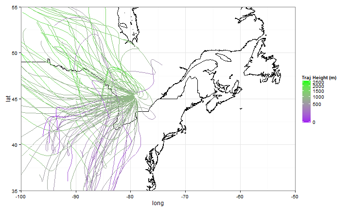

```r
library("ggplot2")
data(countriesHigh)
map_df = fortify(countriesHigh)  #make map data ggplot ready
### change to use the class for shape mapping
plt = ggplot() + geom_path(data = map_df, aes(x = long, y = lat, group = group))
# group defines what coordinates are grouped together to form a trajectory
# in this case it is organized by filename and traj_num
plt = plt + geom_path(data = HYSPLIT_data, aes(x = lon, y = lat, group = paste0(filename,
    "_traj", traj_num), colour = height_AGL_in_m))
plt = plt + scale_colour_gradient("Traj Height (m)", low = "purple", high = "green",
    trans = "sqrt")
plt = plt + coord_cartesian(xlim = c(-100, -50), ylim = c(35, 55))

plt = plt + theme_bw()
plt
```

### Creating Spatial Line Objects in R

Let convert the trajectory data into Spatial Objects (shapefiles) to facilitate geospatial processing. In this case, we will be generate a SpatialLines object. See R spatial cheat sheet for more details ([http://www.maths.lancs.ac.uk/~rowlings/Teaching/UseR2012/cheatsheet.html](http://www.maths.lancs.ac.uk/%7Erowlings/Teaching/UseR2012/cheatsheet.html))

```r
library("plyr")
# group and order coordinate to help build the trajectory paths
HYSPLIT_data = arrange(HYSPLIT_data, filename, traj_num, -traj_age_in_hours)
HYSPLIT_data$LINEID = paste0(HYSPLIT_data$filename, "_traj", HYSPLIT_data$traj_num)
HYSPLIT_LineList = dlply(HYSPLIT_data, "LINEID", function(x) {
    traj_coords = subset(x, select = c("lon", "lat"))
    return(Line(traj_coords))
})
# Assemble groups of trajectories under a Lines object and assign an ID base
# on filename
HYSPLIT_Lns = dlply(HYSPLIT_data, .variables = c("filename"), function(x) {
    uniq_traj = unique(x$LINEID)
    uniq_group = unique(x$filename)
    out = Lines(HYSPLIT_LineList[uniq_traj], ID = uniq_group)
    return(out)
})
latlong = "+init=epsg:4326"
HYSPLIT_spL = SpatialLines(HYSPLIT_Lns, proj4string = CRS(latlong))
HYSPLIT_spL[1]
```

```
## An object of class "SpatialLines"
## Slot "lines":
## $`./Trajectories/traj(back)-00-01-01-00-lat_45.24423_long_-78.89389-height_1000-48h`
## An object of class "Lines"
## Slot "Lines":
## $`./Trajectories/traj(back)-00-01-01-00-lat_45.24423_long_-78.89389-height_1000-48h_traj1`
## An object of class "Line"
## Slot "coords":
##           lon   lat
##  [1,]  -79.47 45.22
##  [2,]  -80.05 45.21
##  [3,]  -80.63 45.19
##  [4,]  -81.22 45.19
##  [5,]  -81.82 45.21
##  [6,]  -82.45 45.25
##  [7,]  -83.07 45.31
##  [8,]  -83.67 45.35
##  [9,]  -84.25 45.39
## [10,]  -84.84 45.42
## [11,]  -85.43 45.45
## [12,]  -86.04 45.48
## [13,]  -86.66 45.53
## [14,]  -87.28 45.60
## [15,]  -87.90 45.69
## [16,]  -88.53 45.78
## [17,]  -89.16 45.88
## [18,]  -89.80 46.01
## [19,]  -90.42 46.17
## [20,]  -91.01 46.34
## [21,]  -91.58 46.51
## [22,]  -92.14 46.68
## [23,]  -92.71 46.84
## [24,]  -93.29 46.99
## [25,]  -93.87 47.13
## [26,]  -94.42 47.25
## [27,]  -94.95 47.35
## [28,]  -95.45 47.42
## [29,]  -95.92 47.47
## [30,]  -96.37 47.48
## [31,]  -96.79 47.50
```

[output cut: 17 more lines]

```
##
##
##
## Slot "ID":
## [1] "./Trajectories/traj(back)-00-01-01-00-lat_45.24423_long_-78.89389-height_1000-48h"
##
##
##
## Slot "bbox":
##       min    max
## x -100.95 -79.47
## y   45.19  49.76
##
## Slot "proj4string":
## CRS arguments: +init=epsg:4326
```

### Construct a raster object

```r
library("raster")
library("ggplot2")
rast1 = raster(xmn = -100, xmx = -50, ymn = 35, ymx = 55, nrows = 40, ncol = 100,
    crs = CRS(latlong))
traj_dens = rasterize(x = HYSPLIT_spL, rast1, fun = "count")

traj_dens_df = data.frame(rasterToPoints(traj_dens))
head(traj_dens_df)
```

```
##        x     y layer
## 1 -98.75 54.75     1
## 2 -98.25 54.75     1
## 3 -97.75 54.75     3
## 4 -97.25 54.75     3
## 5 -96.75 54.75     1
## 6 -96.25 54.75     3
```

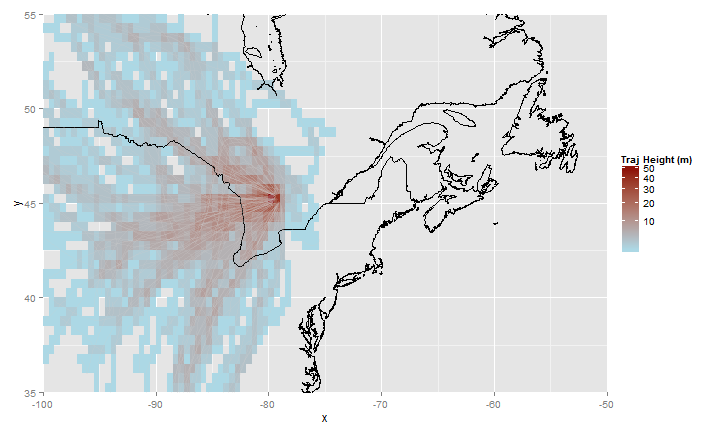

```r
plt = ggplot()
plt = plt + geom_tile(data = traj_dens_df, aes(x = x, y = y, fill = layer))
plt = plt + geom_path(data = map_df, aes(x = long, y = lat, group = group))
plt = plt + geom_path(data = HYSPLIT_data, aes(x = lon, y = lat, group = paste0(filename,
    "_traj", traj_num)), colour = "grey80", alpha = 0.2)
plt = plt + scale_fill_gradient("Traj Height (m)", low = "lightblue", high = "darkred",
    trans = "sqrt")
plt = plt + coord_cartesian(xlim = c(-100, -50), ylim = c(35, 55))
plt
```